# Decomposing Okhotsk Diatom Diversity based on sample coverage

Chih-Lin Wei

2026-08-11

```r
## import packages
library(iNEXT.beta3D)
library(readxl)
library(dplyr)
library(plyr)
library(ggplot2)
library(ggpattern)
library(ggrepel)
library(doBy)
library(reshape2)
library(patchwork)
library(vegan)
```

# 1 Load data

```r
large <- theme(legend.title = element_text(size=20),
        legend.text = element_text(size=20),
        axis.title = element_text(size=20),
        axis.text = element_text(size=15),
        strip.text = element_text(size=20))
vert_x <- theme(axis.text.x.bottom = element_text(angle = 45, hjust = 1, face="italic"))
no_strip.x <- theme(strip.background.x = element_blank(),
                  strip.text.x = element_blank())
no_strip.y <- theme(strip.background.y = element_blank(),
                  strip.text.y = element_blank())
no_legend <- theme(legend.position = "none")

# Standard error function
se <- function(x, ...)sd(x, ...)/sqrt(length(x))

load(file="../Rdata/mis.rda") # Marine Isotope Stage
load(file="../Rdata/spp.rda") # Raw species count
load(file="../Rdata/sam.rda") # Sample information
load(file="../Rdata/div.rda") # Diversity
```

```r
# Mid-Pleistocene Transition
mis$Period2 <- cut(mis$End, breaks=c(0, 830, 1230, 1600), labels = c("Post", "MPT", "Pre"), right=FALSE)
mis$Period2 <- factor(mis$Period2, levels=c("Pre", "MPT", "Post"))

# Interglacial vs. super interglacial
mis$Period3 <- mis$Period %>% as.character
mis$Period3[mis$MIS==5|mis$MIS==9|mis$MIS==11|mis$MIS==31|mis$MIS==47|mis$MIS==49] <- "Super interglacial"
mis$Period3 <- factor(mis$Period3, levels=c("Interglacial", "Super interglacial",   "Glacial"))
```

# 2 Decomposing diversity using iNterpolation and EXTrapolation based on Hill numbers

We used Hill numbers to decompose gamma diversity into alpha and beta components based on [Whittaker’s (1960)](https://doi.org/10.2307/1943563) multiplicative rule. In the analysis, the gamma diversity represents the effective number of species in the entire assemblage. The alpha diversity reflects the mean joint diversity or the effective number of species-assemblage combinations per actual assemblage. The beta diversity the ratio of gamma to alpha diversities, quantifying the effective number of assemblages based on (unweighted) species raw abundance datasets, ranging from 1 to N, where $beta = 1$ indicates identical species raw abundance datasets across assemblages (i.e., only one assemblage), and $beta = N$ indicates no shared species among assemblages (i.e., N assemblages).

The beta diversity can be normalized into four classes of differentiation measures (or dissimilarity) ranging from zero to one, assessing local overlap, regional overlap, homogeneity, and turnover. We use $1-C$, the standardized Sørensen-type non-overlap index, which measures the average proportion of non-shared species in an assemblage and corresponds to the classic Sørensen, Horn, and Morisita-Horn dissimilarities for $q = 0, 1$, and $2$ , respectively.

Other dissimilarity indexes include standardized Jaccard-type non-overlap index, $1-U$, represents the proportion of non-shared species in the pooled assemblage. Standardized Sørensen-type turnover index, $1-V$, captures species turnover relative to alpha diversity. Standardized Jaccard-type turnover index, $1-S$, measures species turnover relative to gamma diversity.

All diversity and dissimilarity measures were standardized using sample coverage (=95%) derived from the interpolation and extrapolation of Hill numbers accumulation curves, based on 1000 bootstrap resampling. The mean and 95% confidence interval of the bootstrap estimates are reported.

For more details, see [Chao et al. (2023)](https://doi.org/10.1002/ecm.1588), [Chao et al. (2019)](https://doi.org/10.1111/2041-210X.13233), [Chiu et al. (2014)](https://doi.org/10.1890/12-0960.1), and [Chao et al. (2016)](https://link.springer.com/chapter/10.1007/978-3-319-22461-9_8).

# 3 Gamma, alpha, and beta diversity for each MIS stage

```r
# Split the census data into list of MIS stage
dl <- splitBy(~MIS, cbind(MIS=sam$MIS, spp), omit = FALSE) %>% lapply(FUN = function(x)x[,-1])
dl <- dl[match(levels(sam$MIS), names(dl))]

# Remove species with zero abundance
dl <- lapply(dl, FUN = function(x) x[rowSums(x)!=0, colSums(x)!=0])

# zero abundance
zero <- lapply(dl, FUN=sum) %>% unlist == 0

# with only 1 sample
only1 <- lapply(dl, FUN=function(x)dim(x)[1]) %>% unlist == 1

# Convert to species as rows and age as columns
dl <- lapply(dl[!(zero|only1)], FUN=function(x)t(x))
```

```r
# Test run to show maximum sample coverage in each region
test <- iNEXTbeta3D(data = dl, q = 0, nboot = 0)
save(test, file="../RData/mis_test.rda")
```

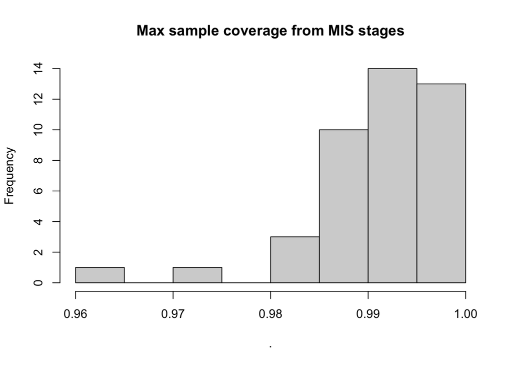

```r
load(file="../RData/mis_test.rda")
maxSC <- lapply(test, FUN = function(x){
  lapply(x, FUN = function(y) {
    names(y)[5] <- "Measure"
    y[dim(y)[1],] # Maximum sample coverage
    }) %>% ldply
  })

# Minimum values the max sample coverage
lapply(maxSC, FUN=function(x)min(x$SC)) %>% unlist %>% hist(main = "Max sample coverage from MIS stages")
```

The sample coverage can be standardized to 0.95.

```r
# It seems that we may set the sample coverage to 0.95
# nboot should change to 1000
est <- iNEXTbeta3D(data = dl, q = c(0, 0.25, 0.5, 0.75, 1, 1.25, 1.5, 1.75, 2), level = 0.95, nboot = 1000)
save(est, file="../RData/mis_div_decomp.rda")
```

```r
load("../RData/mis_div_decomp.rda")
dat <- lapply(est, FUN = function(x){
  lapply(x, FUN = function(y){
    names(y)[5] <- "value"
    return(y)
  }) %>% ldply
}) %>% ldply

dat <- cbind(dat, mis[match(dat$Dataset, mis$MIS),])
```

```r
divplot <- function(data, ylab) {
  ## Descriptive statistics by MIS stages
  # Top x-axis
  ax2 <- subset(mis, Period=="Interglacial")

  # Minimum and maximum ranges of each panel
  ci_range <- data[, c("Order.q", "LCL", "UCL")] %>% melt(id.var="Order.q", variable.name="range") # min and max values of 95% CI
  p_range <- rbind(ci_range[,-2], data[, c("Order.q", "value")]) # combine 95% CI with the Hill numbers

  ax3 <- lapply(splitBy(~Order.q, p_range, omit = FALSE), FUN=function(x)cbind(ax2, ymin=min(x$value, na.rm=T), ymax=max(x$value, na.rm=T))) %>% ldply(.id="Order.q")
  ax3$label <- factor(ax3$Order.q, labels= labs)

  # Mid-Pleistocene Transition
  mpt <- c(Start=830, End=1230) %>% as.data.frame %>% t
  mpt <- lapply(splitBy(~Order.q, p_range, omit = FALSE), FUN=function(x)cbind(mpt, ymin=min(x$value, na.rm=T), ymax=max(x$value, na.rm=T))) %>% ldply(.id="Order.q")
  mpt$label <- factor(mpt$Order.q, labels= labs)

  ggplot()+
  geom_rect_pattern(data=mpt, aes(xmin=Start, xmax=End, ymin=ymin, ymax=ymax), pattern="stripe", pattern_alpha = 0.1, fill="transparent", pattern_density = 0.3, colour="black", linetype = 4)+
  geom_rect(data=ax3, aes(xmin=Start, xmax=End, ymin=ymin, ymax=ymax), fill="gray", colour="transparent", alpha=0.2)+
  geom_rect(data=data, aes(xmin=Start, xmax=End, ymin=LCL, ymax=UCL, fill=Period), alpha=0.6)+
  geom_segment(data=data, aes(x=Start, y=value, xend=End, yend=value, color=Period), alpha=1, linewidth=1)+
  labs(x = "Age (Ka)", y = ylab)+
  scale_fill_viridis_d(direction = -1)+
  scale_colour_viridis_d(direction = -1)+
  scale_x_reverse(expand=expansion(mult = 0.01), breaks=seq(0, 1550, 50), sec.axis = sec_axis(~.*1, breaks = with(ax2, (Start+End)/2), labels = ax2$MIS))+
  scale_y_continuous(expand = expansion(mult = 0.01))+
  facet_wrap(~label, labeller = label_parsed, ncol = 1, scales = "free_y", strip.position="right")+
  theme_bw()%+replace% large %+replace% vert_x
}
```

## 3.1 Gamma diversity

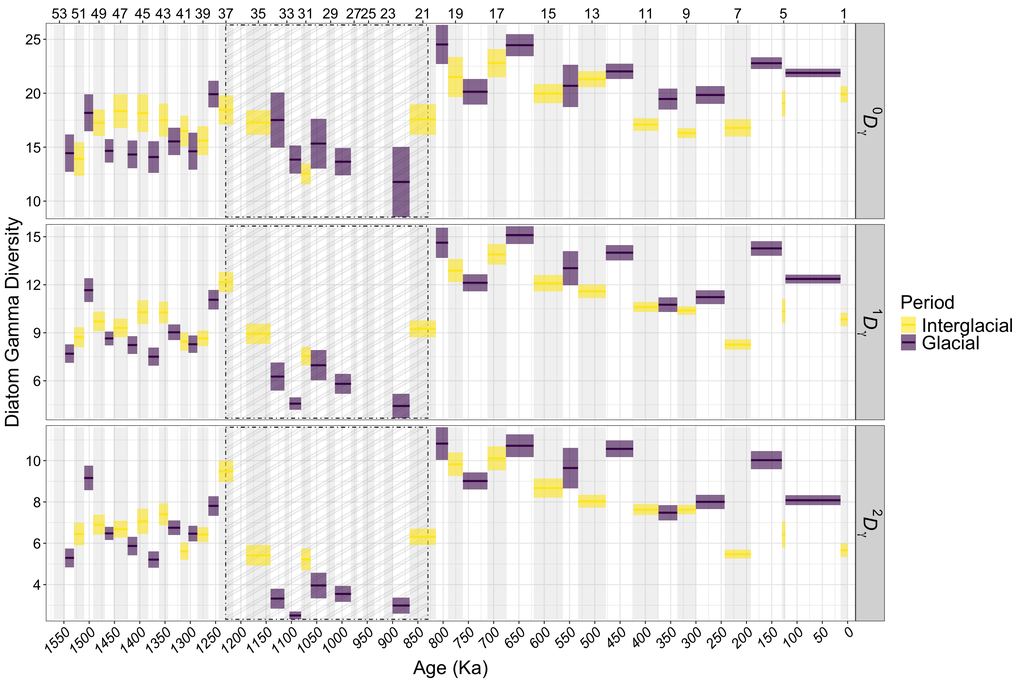

```r
dat2 <- subset(dat, .id=="gamma" & (Order.q==0|Order.q==1|Order.q==2))
labs <- c(expression(""^0*italic(D[gamma])), expression(""^1*italic(D[gamma])), expression(""^2*italic(D[gamma])))
dat2$label <- factor(dat2$Order.q, labels= labs)
divplot(dat2, "Diatom Gamma Diversity")
```

Fig.x. Gamma diversities base on 95% sample coverage among MIS stages. Horizontal lines show the mean diversity estimate and shaded areas show 95% confidence intervals from 1000 bootstrap resampling. The oblique striped area shows Mid-Pleistocene Transition (MPT).

## 3.2 Alpha diversity

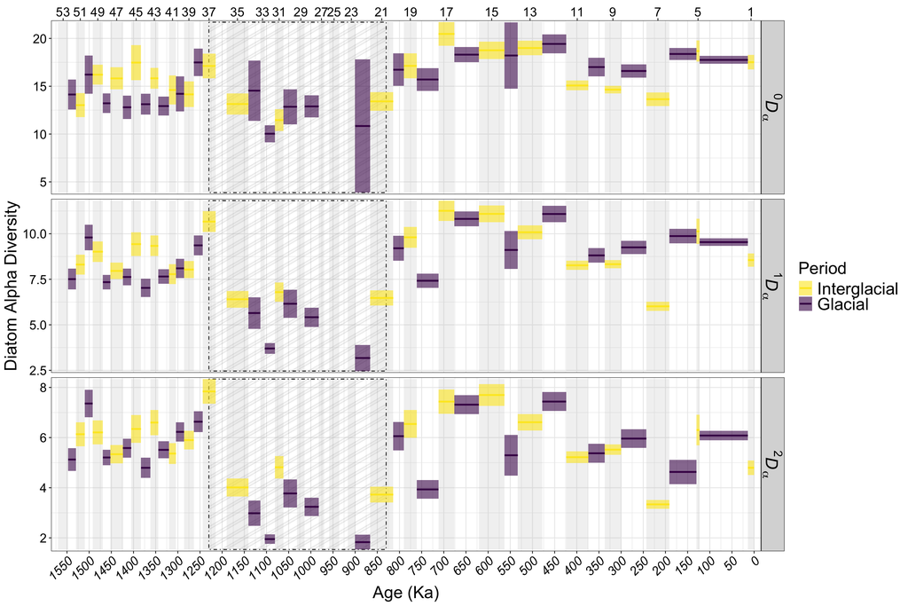

```r
dat2 <- subset(dat, .id=="alpha" & (Order.q==0|Order.q==1|Order.q==2))
labs <- c(expression(""^0*italic(D[alpha])), expression(""^1*italic(D[alpha])), expression(""^2*italic(D[alpha])))
dat2$label <- factor(dat2$Order.q, labels= labs)
divplot(dat2, "Diatom Alpha Diversity")
```

Fig.x. Alpha diversities base on 95% sample coverage among MIS stages. Horizontal lines show the mean diversity estimate and shaded areas show 95% confidence intervals from 1000 bootstrap resampling. The oblique striped area shows Mid-Pleistocene Transition (MPT).

## 3.3 Beta diversity

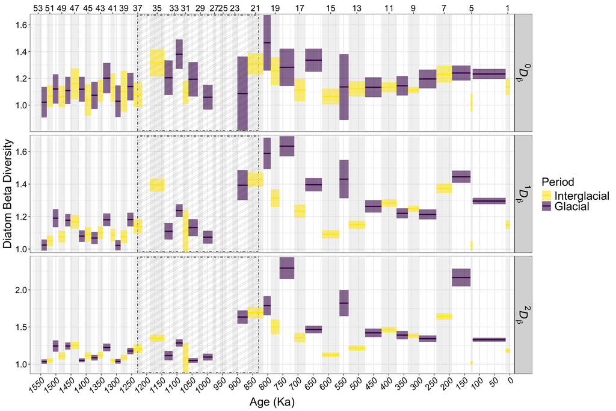

```r
dat2 <- subset(dat, .id=="beta" & (Order.q==0|Order.q==1|Order.q==2))
labs <- c(expression(""^0*italic(D[beta])), expression(""^1*italic(D[beta])), expression(""^2*italic(D[beta])))
dat2$label <- factor(dat2$Order.q, labels= labs)
divplot(dat2, "Diatom Beta Diversity")
```

Fig.x. Beta diversities base on 95% sample coverage among MIS stages. Horizontal lines show the mean diversity estimate and shaded areas show 95% confidence intervals from 1000 bootstrap resampling. The oblique striped area shows Mid-Pleistocene Transition (MPT).

# 4 Dissimilarity

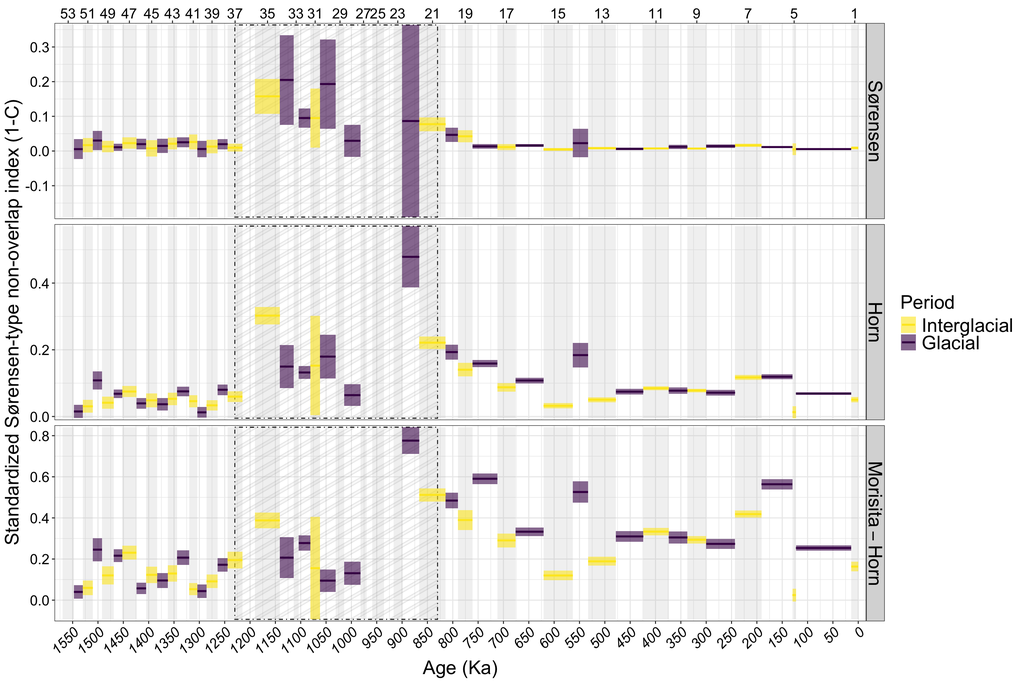

```r
dat2 <- subset(dat, .id=="1-C" & (Order.q==0|Order.q==1|Order.q==2))
labs <- c("Sørensen", "Horn", "Morisita-Horn")
dat2$label <- factor(dat2$Order.q, labels= labs)
divplot(dat2, "Standardized Sørensen-type non-overlap index (1-C)")
```

Fig.x. Dissimilarities base on 95% sample coverage among MIS stages. Horizontal lines show the mean diversity estimate and shaded areas show 95% confidence intervals from 1000 bootstrap resampling. The oblique striped area shows Mid-Pleistocene Transition (MPT).

# 5 Gamma, alpha, and beta diversity for glacial/interglacial in pre-MPT, MPT, and post-MPT

```r
# Split the census data into list of west and east
dl <- splitBy(~Period2+Period, cbind(sam[, c("Period", "Period2")], spp), omit = FALSE) %>% lapply(FUN = function(x)x[,-1:-2])

# Remove species with zero abundance
dl <- lapply(dl, FUN = function(x) x[rowSums(x)!=0, colSums(x)!=0])

# Convert to species as rows and age as columns
dl <- lapply(dl, FUN=function(x)t(x))
```

```r
# Test run to show maximum sample coverage in each region
test <- iNEXTbeta3D(data = dl, q = 0, nboot = 0)
save(test, file="../RData/gig_test.rda")
```

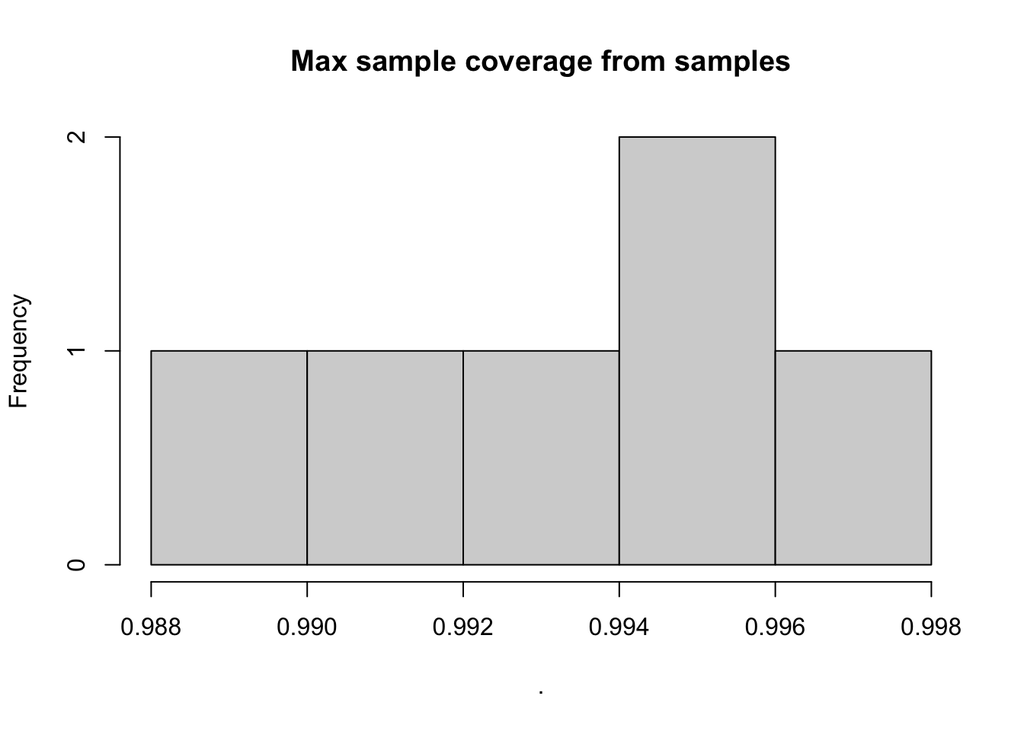

```r
load(file="../RData/gig_test.rda")
maxSC <- lapply(test, FUN = function(x){
  lapply(x, FUN = function(y) {
    names(y)[5] <- "Measure"
    y[dim(y)[1],] # Maximum sample coverage
    }) %>% ldply
  })

# Minimum values the max sample coverage
lapply(maxSC, FUN=function(x)min(x$SC)) %>% unlist %>% hist(main = "Max sample coverage from samples")
```

```r
# It seems that we may set the sample coverage to 0.95
# nboot should change to 1000
est <- iNEXTbeta3D(data = dl, q = c(0, 0.25, 0.5, 0.75, 1, 1.25, 1.5, 1.75, 2), level = 0.95, nboot = 1000)
save(est, file="../RData/gig_div_decomp.rda")
```

```r
load("../RData/gig_div_decomp.rda")
dat <- lapply(est, FUN = function(x){
  lapply(x, FUN = function(y){
    names(y)[5] <- "value"
    return(y)
  }) %>% ldply
}) %>% ldply

fr <- strsplit(dat$Dataset, split="[|]") %>% ldply
dat$Period <- fr$V2
dat$Period <- factor(dat$Period, levels=c("Interglacial",   "Glacial"))
dat$Period2 <- fr$V1
dat$Period2 <- factor(dat$Period2, levels=c("Pre", "MPT", "Post"))
dat$.id <- factor(dat$.id, levels=c("gamma", "alpha", "beta", "1-C", "1-U", "1-V", "1-S"))
```

## 5.1 Diversity

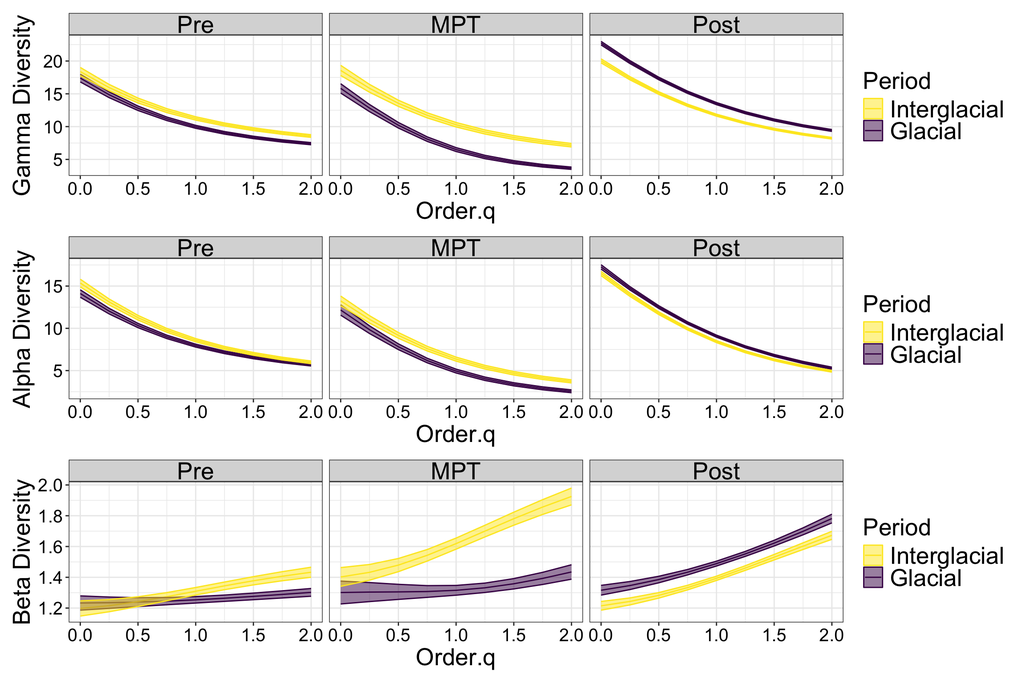

```r
library(Hmisc)

lapply(group_split(dat, .id)[1:3], function(x){
  ggplot(data=x,
       aes(x = Order.q, y = value, ymax = UCL, ymin = LCL, colour = Period, fill = Period, group=Dataset))+
  geom_line()+
  geom_ribbon(alpha = 0.5)+
  labs(y=paste(as.character(x$.id)[1] %>% capitalize, "Diversity"), colour = "Period", fill = "Period")+
  scale_fill_viridis_d(direction = -1)+
  scale_colour_viridis_d(direction = -1)+
  facet_wrap(~Period2)+
  theme_bw() %+replace% large
}) %>% wrap_plots(ncol=1)
```

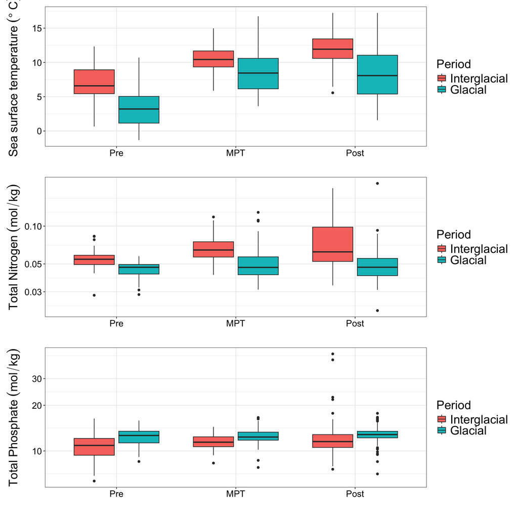

```r
p1 <- ggplot(sam)+
  geom_boxplot(aes(x=Period2, y=SST, fill=Period))+
  labs(x="", y=expression(Sea~surface~temperature~(degree~C)))+
  theme_bw() %+replace% large

p2 <- ggplot(sam)+
  geom_boxplot(aes(x=Period2, y=TN, fill=Period))+
  labs(x="", y=expression(Total~Nitrogen~(mol/kg)))+
  scale_y_log10()+
  theme_bw() %+replace% large

p3 <- ggplot(sam)+
  geom_boxplot(aes(x=Period2, y=TP, fill=Period))+
  labs(x="", y=expression(Total~Phosphate~(mol/kg)))+
  scale_y_log10()+
  theme_bw() %+replace% large

p1/p2/p3
```

Fig.x. Box plots for sea surface temperature, total nitrogen, and total phosphate. Diversity patterns flip after MPT. Perhaps having something to do with the range of SST or TN?